# Seasonal pulses and spatial heterogeneity of published dengue counts in Argentina: a population-ecology perspective

A hypothesis-driven ecological interpretation of reproducible surveillance patterns

## 0.1 Abstract

Dengue arises from coupled interactions among mosquitoes, viruses, human hosts, environments, and systems of observation. This hypothesis-driven ecological perspective uses a certified reproducible descriptive analysis of official Argentine surveillance data as its empirical basis. It is not a new epidemiological study, causal analysis, climate-attribution study, transmission model, or incidence study. In SE31/2024–SE30/2025, the analysis retained 17,844 published counts. The observed national maximum was at season week 36, the weighted temporal center was 35.76 weeks, and the shortest windows containing 50%, 80%, and 90% of published counts lasted 5, 10, and 12 weeks. Regional timing differed, and NEA had a tied rather than unique peak. In calendar year 2024, population adjustment reordered provinces: Buenos Aires was first by published count but sixteenth by published-count rate per 100,000, while Tucumán moved from third to first.

These patterns are consistent with, but do not demonstrate, a seasonally forced vector–virus–host system. The proposed framework separates a latent biological process–linking climate and habitat, mosquito population dynamics, vector–virus biology, and human hosts–from the observation process through which transmission becomes healthcare seeking, detection, notification, classification, geographic assignment, and a published dataset. It explains why population size, habitat, mobility, immunity, serotypes, and surveillance can all shape observed heterogeneity, offers five falsifiable predictions, and specifies independent data required to test them. Published counts remain neither unique people, incidence, individual risk, nor direct measurements of transmission.

**Keywords:** Dengue; *Aedes aegypti*; population ecology; vector ecology; seasonal dynamics; surveillance; Argentina; spatial heterogeneity.

## Resumen en español

Este artículo presenta una interpretación ecológica orientada por hipótesis de patrones descriptivos certificados de vigilancia de dengue en Argentina. No es un nuevo estudio epidemiológico ni una demostración causal. Para la temporada SE31/2024–SE30/2025, el análisis reproducible de datos oficiales publicados retuvo 17.844 conteos publicados; el máximo nacional observado fue la semana estacional 36 y la concentración temporal fue marcada. Los descriptores regionales fueron heterogéneos; en NEA el máximo fue un empate y no una semana única. Para el año calendario 2024, el ajuste por población reordenó los territorios: Buenos Aires pasó del primer lugar por conteo publicado al decimosexto por tasa de conteos publicados por 100.000, mientras Tucumán pasó del tercero al primero.

La hipótesis considera un sistema estacional vector–virus–huésped. Distingue el proceso biológico latente –hábitat, dinámica de *Aedes aegypti*, biología vector–virus y población humana– del proceso de observación mediante el cual la transmisión puede llegar a atención sanitaria, detección, notificación, clasificación, asignación geográfica y datos publicados. La contribución es conceptual: los patrones son compatibles con mecanismos ecológicos, pero no los demuestran. Se proponen predicciones falsables y la evidencia independiente que sería necesaria para evaluarlas. Los conteos publicados no son personas únicas, incidencia ni riesgo individual.

# 1 Introduction

Dengue is a coupled vector–virus–host–environment system, not simply a time series of reported disease. Temperature and its daily variation can affect mosquito development, survival, reproduction, infection, and extrinsic incubation, often nonlinearly (Mordecai et al. 2019; Lambrechts et al. 2011; Carrington, Seifert, et al. 2013). Habitat and urban form determine where mosquitoes can persist; human population distribution and daily movement shape vector–host contact; and immunity and circulating serotypes alter the susceptible host population.

Argentina is informative because it spans heterogeneous climatic and ecological environments. Field work in Buenos Aires, Córdoba, the Northwest, and the Northeast documents seasonal and spatial variation in *Aedes aegypti* abundance or oviposition, and the importance of temperature, weather, microhabitat, and urban conditions (Vezzani et al. 2004, 2005; De Majo et al. 2013; Benitez et al. 2021; Estallo et al. 2015; Gimenez et al. 2020; Montini et al. 2021). Evidence of long-term vector dynamics and range expansion makes ecological interpretation relevant, but does not make climate sufficient to explain a particular surveillance pattern (Fischer et al. 2017; Rubio et al. 2020).

This article interprets the completed *Argentina Dengue Surveillance* project, a reproducible contract-first descriptive analysis of official public releases. Its certified report is available [online](https://etalii.github.io/scientific-data-portfolio/argentina-dengue-analysis/). The project distinguishes absolute published counts from published-count rates per 100,000. Population size can contribute to an absolute numerator, while population adjustment can reveal that population size alone does not summarize territorial heterogeneity. It does not turn reported counts into incidence, individual risk, infection probability, or a direct measurement of transmission intensity.

Our objective is to formulate an ecological hypothesis that organizes the certified descriptive patterns, identifies competing explanations, and specifies independent evidence needed to test them. We do not claim that the surveillance analysis tests the hypothesis.

# 2 Empirical basis and analytical boundaries

The project consumes official Argentine surveillance releases and, for calendar-year geographic displays, official INDEC population denominators. It produces a reproducible description of published counts, published-count rates per 100,000, documented geographic assignment, and observed temporal descriptors. It does not identify people, deduplicate epidemiological cases, or estimate latent infections.

Two scopes are intentionally non-interchangeable. The seasonal scope, SE31/2024–SE30/2025, contains 17,844 published counts. Its observed national maximum is season week 36; its weighted temporal center is 35.76356 and its weighted median is week 36. The shortest contiguous observed windows reaching 50%, 80%, and 90% of the total are 5, 10, and 12 weeks. It retains 678 published counts with unknown or nonassignable geography, and geographic mapping completeness is 96.2%. This describes assignment within scope, not surveillance completeness.

The geographic comparison uses calendar year 2024 and a contemporary denominator scenario. Its territorial numerators include only geographically mapped published counts; 27,220 national published counts lack provincial geography and are not redistributed. A published-count rate per 100,000 is not incidence, an attack rate, individual risk, or a complete territorial numerator. No cumulative cross-year seasonal rate is reported.

The data do not support claims about unique people, transmission chains, epidemic propagation, causal effects, or unobserved regional zeros. Missing region-week rows remain missing rather than zero-filled. They also do not support direct epidemiological comparison of annual totals for 2018, 2022, 2024, and 2025, or age-specific rates. These observations are the endpoint of a surveillance process, not direct measurements of the biological system that generated infections.

# 3 Ecological hypothesis and testable predictions

## 3.1 Central hypothesis

The temporal concentration and geographic heterogeneity of published dengue counts in Argentina are consistent with a seasonally forced vector–virus–host system. In this hypothesis, local transmission potential can increase when *Aedes aegypti* population dynamics and temperature-dependent vector–virus processes encounter favourable seasonal conditions within particular human and urban settings. Human population size contributes importantly to absolute published counts. Habitat, human–vector contact, mobility, viral introduction, host susceptibility, serotype circulation, and the observation process can all modify population-adjusted published patterns.

This is a hypothesis about a latent system. The certified findings are compatible with it, but do not identify its parameters or demonstrate a mechanism. Climate, mosquito abundance, mobility, immunity, serotypes, and healthcare use were not measured in the analysis and must not be inferred from the reported patterns.

## 3.2 Falsifiable predictions

The following predictions are deliberately framed so that independent evidence could weaken as well as support the ecological hypothesis.

1. **Seasonal vector suitability.** If seasonal vector ecology is important, measured adult or immature mosquito abundance, or a pre-specified climate-derived suitability measure, should systematically precede or overlap the surveillance rise with biologically plausible lags. Weekly mosquito surveillance and weather data, linked at compatible places and times, are required. Repeated strong surveillance peaks during periods of low measured vector suitability would weaken this component of the hypothesis.
2. **Population size and territorial reordering.** If population size explains only part of the spatial pattern, absolute published counts should relate strongly to population size while population-adjusted published patterns retain structured heterogeneity associated with independently measured ecological or contact conditions. Comparable population, habitat, entomological, and mobility data are required. If adjusted patterns show no reproducible heterogeneity once measurement quality is assessed, this prediction would be weakened.
3. **Regional seasonal heterogeneity.** If differing local seasonal conditions matter, regional timing should covary with independently measured thermal regimes, habitat, or vector phenology rather than simply reflecting a common schedule. Harmonized region-week entomological and environmental series are required. Stable identical timing across ecologically contrasting regions, after comparable observation, would weaken this prediction.
4. **Introductions and connectivity.** If mobility and viral introduction are important, changes in local surveillance patterns should align with independently documented travel, importation, or viral-lineage evidence in receptive vector populations. Travel histories, mobility measures, and genomic surveillance are required. Strong local pulses repeatedly occurring without compatible introduction or connectivity evidence would weaken this explanation.
5. **Host susceptibility and serotypes.** If susceptible fraction and serotype circulation modify epidemic magnitude, otherwise similar vector and habitat settings should differ in their published patterns in ways that correspond to independent seroprevalence and virological data. Longitudinal serological and serotype surveillance are required. Consistent magnitude despite sharply different measured susceptibility or serotype conditions would weaken this component.

These predictions are not tested here. They also are not mutually exclusive: support for one would not eliminate the need to evaluate the others or the observation process.

# 4 Two-process conceptual framework

The central conceptual contribution is to separate what is biologically latent from what is observed administratively. The observed surveillance signal is the joint product of an underlying biological system and an observation process. The first process concerns conditions under which infections may occur; the second concerns how some resulting events become published records.

```
flowchart TB
  subgraph latent[Latent biological process]
    C[Climate and habitat] --> M[Aedes aegypti population dynamics]
    M --> V[Vector-virus processes]
    V --> H[Human host population]
    H --> T[Transmission]
    U[Urban habitat] --> M
    U --> H
    X[Human mobility] --> H
    X --> T
    I[Host immunity] --> H
    S[Serotype circulation] --> H
    S --> V
  end
  subgraph observation[Observation process]
    T --> D[Healthcare seeking and detection]
    D --> N[Notification]
    N --> CL[Classification]
    CL --> G[Geographic assignment]
    G --> P[Published surveillance dataset]
  end
```

**Figure 1. Conceptual framework.** The upper process represents hypothesized biological relationships; the lower process represents the pathway through which transmission may become a published surveillance record. This is not an estimated causal model.

The latent process includes mosquito recruitment, immature development, adult survival, oviposition, biting, infection, extrinsic incubation, and survival to infectiousness. It also includes the size and structure of human populations, their contact with vectors, mobility, immunity, and circulating serotypes. The observation process includes healthcare contact, detection, notification, classification, and geographic assignment. The certified project directly analyzes the endpoint of the second process, not the latent biological process itself.

This distinction is useful as a cautious *ecology of observation*: the ability to infer biological dynamics depends on how biological events pass through healthcare contact and institutional recording. It does not presume the magnitude or direction of any under-ascertainment in this dataset. Rather, it requires that differences among published signals be interpreted as potentially shaped by both systems until appropriate independent evidence is available.

# 5 Biological interpretation of certified patterns

## 5.1 Seasonal concentration

The certified season has a concentrated national published-count profile: half of its total falls within the shortest five-week observed window, 80% within ten weeks, and 90% within twelve weeks. Its observed maximum and weighted median both occur at season week 36, while its weighted temporal center is approximately 35.76. A concentrated pulse is biologically compatible with a seasonally forced vector–host system: recruitment and development of immature mosquitoes, seasonal adult survival, oviposition, biting, and temperature-dependent vector–virus processes can overlap with changing human exposure during a limited interval. Seasonal patterns of *Ae. aegypti* abundance and oviposition in Argentina make that interpretation biologically plausible (Vezzani et al. 2004; Fischer et al. 2017; Estallo et al. 2015).

Compatibility is not attribution. The curve contains published counts, not temperature, rainfall, entomological abundance, infection onset, human movement, or viral-introduction data. It cannot establish that temperature, mosquito abundance, or rainfall caused the week-36 maximum; infer a lag; or estimate vectorial capacity. The concentration windows summarize observations in the configured scope. They do not define true epidemic duration or the duration of latent transmission.

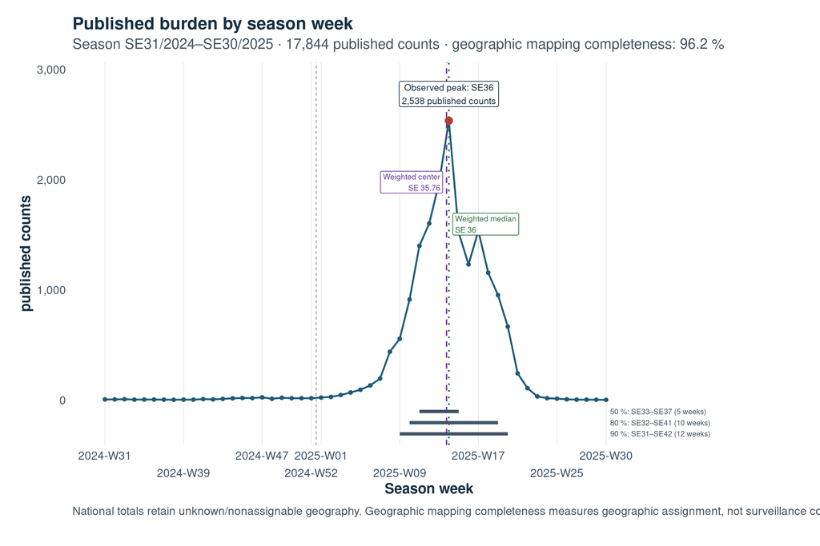

Figure 1: National seasonal profile of published counts for SE31/2024–SE30/2025. It retains unknown or nonassignable geography, identifies the observed peak at SE36, and displays certified concentration descriptors.

**Figure 2.** National published-count profile in the configured season. It describes published observations, not complete surveillance or latent transmission.

## 5.2 Regional observed timing

Regional descriptors differ across observed region weeks. Centro’s unique peak is at season week 36, Cuyo’s at 32, NOA’s at 33, and Sur’s at 34; NEA has a tie at weeks 17 and 38. That tie prevents selection of an arbitrary single NEA peak. Observed regional-week coverage also varies from 18 weeks in Sur to 52 in NEA.

The heterogeneity is compatible with regional variation in thermal regimes, urban habitat, vector population dynamics, mobility, introductions, and host susceptibility. Each is a hypothesis, not an interpretation established by the figure. In particular, the descriptors do not show geographic propagation or identify a route between regions. Missing region-week rows are not zero-filled, so the absence of a row cannot be read as absence of dengue, transmission, or reporting.

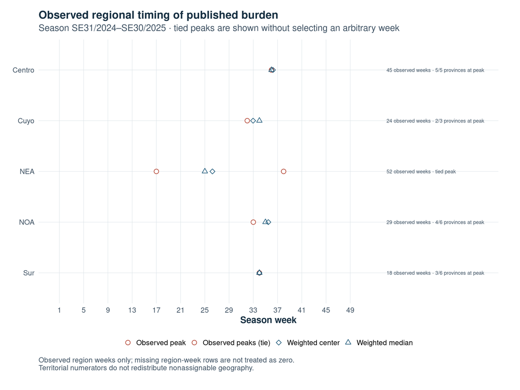

Figure 2: Observed regional timing descriptors for published counts in SE31/2024–SE30/2025. NEA has a tied observed peak, and missing region-week rows are not treated as zero.

**Figure 3.** Regional observed timing descriptors, using observed region weeks only and preserving the NEA peak tie.

## 5.3 Absolute counts and population-adjusted patterns

In calendar-year 2024, Buenos Aires ranks first by published count and sixteenth by published-count rate per 100,000. Tucumán moves from third to first, La Rioja from twelfth to second, and Catamarca from thirteenth to fourth. These rank shifts show that population size and population-adjusted published counts answer different descriptive questions. A large population can contribute to a large numerator. A smaller population can yield a higher published-count rate without establishing greater individual risk or a higher true transmission level.

The result is compatible with heterogeneous ecological and social conditions, but it does not measure ecological suitability. Urban habitat, human–vector contact, vector abundance, mobility or introductions, immunity, serotypes, and reporting may all contribute to the ordering after population adjustment. The strongest inference is therefore descriptive: population size alone does not summarize territorial published patterns. The rank shifts do not identify which process is responsible, and provincial numerators exclude unknown or nonassignable geography.

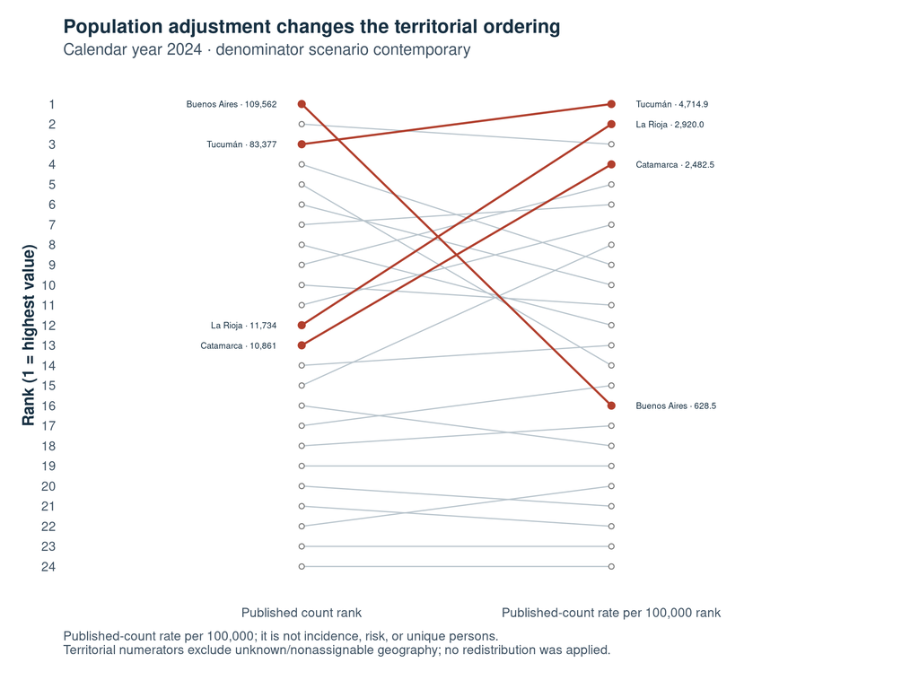

Figure 3: Provincial rank shifts between published count and published-count rate per 100,000 in calendar year 2024. Territorial numerators exclude unknown or nonassignable geography and the rate is not incidence or individual risk.

**Figure 4.** Population adjustment changes provincial ordering in calendar year 2024 under the contemporary denominator scenario.

## 5.4 Regional contrast

Centro has the largest geographically mapped regional published count, whereas NOA has the largest regional published-count rate per 100,000. This parallel with the provincial rank shifts is consistent with the premise that population structure and ecological heterogeneity can contribute differently to absolute and population-adjusted patterns. It does not establish a regional ecological gradient: territorial numerators exclude unknown or nonassignable geography, and neither regional rate measures incidence nor attributes a biological mechanism.

# 6 Discussion

## 6.1 Seasonal forcing and mosquito population ecology

*Aedes aegypti* populations are not static. Recruitment depends on eggs entering available breeding sites; immature development and mortality depend on local temperature and water conditions; adults must survive, obtain blood meals, and oviposit to sustain future cohorts. Container availability, water storage, rainfall, household practices, and built environments can alter this sequence locally. Seasonal population growth or decline consequently reflects a chain of life-history processes rather than a single environmental variable. In Buenos Aires, vector activity and infestation vary substantially across the year (Vezzani et al. 2004), while microclimatic heterogeneity can create short-distance differences (De Majo et al. 2013). In Orán and Córdoba, oviposition has been associated with weather and environmental variables with context-specific lags (Estallo et al. 2015; Benitez et al. 2021).

This biology matters because adult abundance can affect the opportunity for human–vector contact, but abundance alone is not a sufficient measure of transmission potential. A large mosquito population may coexist with limited viral introduction, lower vector infection, reduced survival through the extrinsic incubation interval, a small susceptible fraction, or a surveillance signal that does not mirror all infections. Conversely, a modest abundance at a critical time may still contribute to observed transmission when other conditions align. The manuscript therefore treats mosquito population dynamics as one component of a coupled system, not as a direct proxy for published counts.

Precipitation is especially unsuitable for a universal account: its effects can depend on container types, water management, rainfall intensity, and locality. The appropriate language is “consistent with,” “may modify,” and “requires direct measurement,” rather than climate determinism. Argentine national-scale work likewise frames climate alongside demographic and regional processes rather than as a solitary determinant (Carbajo et al. 2018; López et al. 2023).

## 6.2 From mosquito abundance to transmission potential

Vectorial capacity is a useful conceptual bridge between mosquito population dynamics and transmission, not an estimated quantity in this project. It depends on more than abundance: biting and contact, survival, infection and vector competence, the duration of extrinsic incubation, and survival long enough to become infectious all matter. Temperature can affect several of these traits nonlinearly, and the trait that limits transmission can differ across thermal conditions (Mordecai et al. 2019). Daily thermal fluctuation can alter mosquito survival and competence, so mean temperature alone can obscure relevant biological variation (Lambrechts et al. 2011; Carrington, Seifert, et al. 2013; Carrington, Armijos, et al. 2013).

The certified surveillance profile cannot distinguish a pulse produced by seasonal mosquito demography from one shaped principally by introductions, host susceptibility, or observation. A future evaluation would need linked meteorological series, measures of immature and adult vectors, virus detection or competence evidence, and an explicitly specified observation model. Such a design could ask whether changes in vector-related conditions consistently precede the published signal, rather than retrospectively assigning the observed peak to a single driver.

## 6.3 Human populations as ecological components

Human populations are more than denominators. Their size can affect absolute published counts, but the susceptible fraction, previous exposure, serotype-specific immunity, movement, daily activity, housing, and patterns of human–vector contact can modify epidemic magnitude under superficially similar environmental conditions. A receptive vector population does not by itself imply the same opportunity for viral introduction, amplification, or observation in every place.

Argentine serological studies demonstrate that antibody prevalence and serotype information can be measured independently and can vary geographically (Flichman et al. 2022; Macchia et al. 2025; Biscayart et al. 2025). These studies do not identify the immunity or serotype histories of the people represented in the certified artifacts. No individual serostatus, serotype, genomic lineage, or prior-infection history is present here. Host immunity and serotypes therefore remain alternative explanations and future measurement targets, not retrospective explanations for the reported peak or rank shifts.

## 6.4 Spatial heterogeneity, habitat, and contact

The provincial and regional rank shifts make a narrow but important point: population size does not exhaust the information in territorial published counts. Urban form, housing, water storage, container habitat, socioeconomic conditions, and human–vector contact can create local contrasts in mosquito habitat and exposure. In Buenos Aires, travel, housing, and socioeconomic conditions were relevant to heterogeneous local dengue transmission during the 2016 event (Gurevitz et al. 2021). Northern Argentine studies also document spatially structured and temporally unstable mosquito habitat patterns (Garelli et al. 2013; Espinosa et al. 2016).

This evidence supports a plausible mechanism at its own geographic and measurement scales. It does not translate a high published-count rate into suitability, nor does it establish that La Rioja, Catamarca, Tucumán, or NOA had any particular ecological condition in the certified scope. Instead, the rank shifts motivate the testable expectation that appropriately measured ecological and social conditions could account for variation beyond population size. That expectation requires compatible-scale data and explicit treatment of the observation process.

## 6.5 Mobility and viral introductions

Human movement can couple territories by moving infected people between places with different vector and host conditions. Travel was part of the Buenos Aires analysis (Gurevitz et al. 2021), and mobility is a recognized explanatory mechanism in dengue research and infectious-disease synthesis (Stoddard et al. 2013; Lessani et al. 2024). An introduction into a receptive vector and host setting could help generate a local pulse even when local environmental suitability is similar to that of a place without a documented introduction.

A metapopulation analogy is useful conceptually, but the regional timing figure does not document routes of spread. Mobility and importation compete with a purely local ecological explanation and can also operate alongside it. Travel histories, commuting or mobility measures, virus genomes, and data on likely introduction events would be needed to distinguish these pathways. The descriptive timing differences should not be described as geographic propagation.

## 6.6 Competing explanations

The ecological hypothesis must be evaluated against explanations that can produce part of the same certified patterns. First, a demographic explanation expects population size to contribute strongly to absolute counts; the population-adjusted rank shifts show only that it is not the entire descriptive story. Population data paired with like-for-like territorial numerators would clarify its contribution. Second, mobility and viral introductions can shape the timing and magnitude of local events; travel, genomic, and importation evidence would help distinguish this from locally generated variation. Third, urban habitat, housing, water-storage practices, and socioeconomic heterogeneity can alter breeding opportunities and contact; fine-scale entomological and social measurements would be needed to assess that mechanism.

Fourth, immunity, susceptible fraction, and serotype circulation can modify the human host component even under similar vector conditions; serial seroprevalence and virological surveillance would be needed to evaluate this possibility. Fifth, the surveillance and reporting process can modify which biological events become published records. These processes are not mutually exclusive. No observed rank, peak, or concentration window is uniquely diagnostic of one of them.

## 6.7 Surveillance as an observation process

Surveillance is not merely a caveat; it conditions inference. Reporting delays, healthcare seeking, detection, laboratory capacity, definitions, classification, notification, geographic assignment, and publication can each shape the endpoint that is observed. Dengue surveillance literature documents variation in ascertainment and operational performance (Runge-Ranzinger et al. 2014; Susong et al. 2026). Argentine and regional guidance establish detection, notification, and classification as distinct institutional stages (Ministerio de Salud de la Nación Argentina 2025; Pan American Health Organization 2023). Regional systematic-review evidence likewise emphasizes heterogeneity in dengue surveillance and interpretation (Torres et al. 2017).

The certified project preserves unknown geography, does not complete missing regional weeks, and retains source duplicate/conflict evidence rather than silently resolving it. It lacks individual identifiers and analyzes published counts rather than known unique cases. These properties make the two-process framework practically important: a published surveillance pattern can differ from a biological transmission pattern because the observation process has its own structure. This does not mean every difference is surveillance bias or reporting artefact, and it does not estimate under-ascertainment. It means that biological interpretation must remain conditional on evidence about both processes.

## 6.8 Why annual snapshots do not establish ecological trends

This article does not infer climate-change trends, vector adaptation, increasing transmission, or epidemic growth from the 2018, 2022, 2024, and 2025 annual snapshots. The certified project considers direct annual/interannual comparison unsupported because coverage, schemas, semantic evidence, and observation conditions differ. External literature may motivate hypotheses about climatic suitability or range dynamics (Fischer et al. 2017; López et al. 2023), but cannot convert these four snapshots into a within-project trend analysis.

## 6.9 What evidence would test the hypothesis

The five predictions define the minimum evidence needed for a future evaluation. Weekly meteorological series and repeated immature and adult mosquito measures would be needed to assess temporal suitability and population dynamics. Comparable habitat, land-cover, housing, water-storage, contact, and population data would be needed to evaluate spatial heterogeneity. Travel, commuting, importation, and viral genomic data would be needed to assess connectivity and introductions. Seroprevalence, serotype, and longitudinal immunity data would be needed to assess the host component. Finally, any inferential design needs an observation component covering healthcare contact, detection, notification, classification, and geographic assignment.

These additions would enable pre-specified tests that can fail as well as succeed. They would not eliminate uncertainty automatically, but they would separate an ecological explanation from demographic, mobility, immunity, and surveillance alternatives more rigorously than descriptive surveillance patterns alone can do.

# 7 Conclusions

The certified analysis identifies a concentrated seasonal pulse of published counts and substantial spatial heterogeneity in the relationship between absolute and population-adjusted published counts. These patterns are biologically consistent with a seasonally forced vector–virus–host system, but they do not resolve the mechanisms that generated them. Population size is consequential for absolute counts, yet rank shifts show why it is not the sole descriptive component of territorial heterogeneity.

The central conclusion is deliberately limited: a published surveillance dataset is the endpoint of an observation process, not a direct view of latent transmission. Treating the observed signal as the joint product of biological and observation processes preserves the value of reproducible descriptive evidence while avoiding causal claims it cannot support. Independent entomological, environmental, mobility, virological, serological, and surveillance-process data are required to test the hypothesis.

## References

Benitez, Elisabet M., Elizabet L. Estallo, Marta G. Grech, et al. 2021. “Understanding the Role of Temporal Variation of Environmental Variables in Predicting Aedes aegypti Oviposition Activity in a Temperate Region of Argentina.” *Acta Tropica* 216: 105744. https://doi.org/10.1016/j.actatropica.2020.105744.

Biscayart, Cristián et al. 2025. “Prevalence of Antibodies Against Dengue Virus in the City of Buenos Aires: Results of a Probabilistic Population Survey.” *PLOS Neglected Tropical Diseases*, e0012886. https://doi.org/10.1371/journal.pntd.0012886.

Carbajo, Aníbal Eduardo, María Victoria Cardo, Pilar Consuelo Guimarey, et al. 2018. “Is Autumn the Key for Dengue Epidemics in Non-Endemic Regions? The Case of Argentina.” *PeerJ* 6: e5196. https://doi.org/10.7717/peerj.5196.

Carrington, Lauren B., M. Veronica Armijos, Louis Lambrechts, Christopher M. Barker, and Thomas W. Scott. 2013. “Effects of Fluctuating Daily Temperatures at Critical Thermal Extremes on Aedes aegypti Life-History Traits.” *PLOS ONE* 8 (3): e58824. https://doi.org/10.1371/journal.pone.0058824.

Carrington, Lauren B., Stephanie N. Seifert, Neil H. Willits, Louis Lambrechts, and Thomas W. Scott. 2013. “Large Diurnal Temperature Fluctuations Negatively Influence Aedes aegypti Life-History Traits.” *Journal of Medical Entomology* 50 (1): 43–51. https://doi.org/10.1603/ME11242.

De Majo, María Sol, Sylvia Fischer, Marcelo Otero, and Nicolás Schweigmann. 2013. “Effects of Thermal Heterogeneity and Egg Mortality on Differences in the Population Dynamics of Aedes aegypti over Short Distances in Temperate Argentina.” *Journal of Medical Entomology* 50 (3): 543–51. https://doi.org/10.1603/ME12211.

Espinosa, Manuel, David Weinberg, Camilo H. Rotela, Francisco Polop, Mariana Abril, and Claudio M. Scavuzzo. 2016. “Temporal Dynamics and Spatial Patterns of Aedes aegypti Breeding Sites, in the Context of a Dengue Control Program in Tartagal (Salta Province, Argentina).” *PLOS Neglected Tropical Diseases* 10 (5): e0004621. https://doi.org/10.1371/journal.pntd.0004621.

Estallo, Elizabet L., Francisco F. Ludueña-Almeida, María V. Introini, Mario Zaidenberg, and Walter R. Almirón. 2015. “Weather Variability Associated with Aedes aegypti Oviposition Dynamics in Northwestern Argentina.” *PLOS ONE* 10 (5): e0127820. https://doi.org/10.1371/journal.pone.0127820.

Fischer, Sylvia, María Sol De Majo, Lucía Quiroga, Mariana Paez, and Nicolás Schweigmann. 2017. “Long-Term Spatio-Temporal Dynamics of the Mosquito Aedes aegypti in Temperate Argentina.” *Bulletin of Entomological Research* 107 (2): 225–33. https://doi.org/10.1017/S0007485316000869.

Flichman, Diego Martín, Matías Javier Pereson, Patricia Baré, Sonia Lorena Espindola, Graciela Mabel Carballo, et al. 2022. “Epidemiology of Dengue in Argentina: Antibodies Seroprevalence in Blood Donors and Circulating Serotypes.” *Journal of Clinical Virology* 147: 105078. https://doi.org/10.1016/j.jcv.2022.105078.

Garelli, Fernando M., Manuel O. Espinosa, and Ricardo E. Gürtler. 2013. “Spatial Analysis of Aedes aegypti Immatures in Northern Argentina: Clusters and Temporal Instability.” *Acta Tropica* 128 (3): 461–67. https://doi.org/10.1016/j.actatropica.2013.07.019.

Gimenez, J. O., C. N. Alvarez, W. R. Almirón, and M. Stein. 2020. “Meteorological Variables Associated with the Temporal Oviposition Rate of Aedes aegypti in Resistencia City, Chaco Province, Northeastern Argentina.” *Acta Tropica* 212: 105678. https://doi.org/10.1016/j.actatropica.2020.105678.

Gurevitz, Juan Manuel, Julián Gustavo Antman, Karina Laneri, and Juan Manuel Morales. 2021. “Temperature, Traveling, Slums, and Housing Drive Dengue Transmission in a Non-Endemic Metropolis.” *PLOS Neglected Tropical Diseases* 15 (6): e0009465. https://doi.org/10.1371/journal.pntd.0009465.

Lambrechts, Louis, Krijn P. Paaijmans, Thanyalak Fansiri, et al. 2011. “Impact of Daily Temperature Fluctuations on Dengue Virus Transmission by Aedes aegypti.” *Proceedings of the National Academy of Sciences* 108 (18): 7460–65. https://doi.org/10.1073/pnas.1101377108.

Lessani, M. Naser, Zhenlong Li, Fengrui Jing, et al. 2024. “Human Mobility and the Infectious Disease Transmission: A Systematic Review.” *Geo-Spatial Information Science* 27 (6): 1824–51. https://doi.org/10.1080/10095020.2023.2275619.

López, María S., Andre A. Gómez, Gabriela V. Müller, Elisabet Walker, Michael A. Robert, and Elizabet L. Estallo. 2023. “Relationship Between Climate Variables and Dengue Incidence in Argentina.” *Environmental Health Perspectives* 131 (5): 057008. https://doi.org/10.1289/EHP11616.

Macchia, Alejandro, Daniel Ferrante, Cristián Biscayart, et al. 2025. “Dengue Outbreaks and Antibody Seroprevalence in Buenos Aires.” *American Journal of Tropical Medicine and Hygiene* 113 (4): 865–69. https://doi.org/10.4269/ajtmh.25-0148.

Ministerio de Salud de la Nación Argentina. 2025. *Guía de Vigilancia Epidemiológica y Laboratorial de Dengue y Otros Arbovirus*. https://www.argentina.gob.ar/sites/default/files/2019/10/guia-vigilancia-dengue-otros-arbovirus_version_marzo_2025-vf.pdf.

Montini, Pedro, María Sol De Majo, and Sylvia Fischer. 2021. “Delayed Mortality Effects of Cold Fronts During the Winter Season on Aedes aegypti in a Temperate Region.” *Journal of Thermal Biology* 95: 102808. https://doi.org/10.1016/j.jtherbio.2020.102808.

Mordecai, Erin A., Jamie M. Caldwell, Marissa K. Grossman, Catherine A. Lippi, Leah R. Johnson, et al. 2019. “Thermal Biology of Mosquito-Borne Disease.” *Ecology Letters* 22 (10): 1690–708. https://doi.org/10.1111/ele.13335.

Pan American Health Organization. 2023. *Case Definitions, Clinical Classification, and Disease Phases: Dengue, Chikungunya, and Zika*. https://www.paho.org/en/documents/case-definitions-clinical-classification-and-disease-phases-dengue-chikungunya-and-zika.

Rubio, Alejandra, María Victoria Cardo, Darío Vezzani, and Aníbal Eduardo Carbajo. 2020. “Aedes aegypti Spreading in South America: New Coldest and Southernmost Records.” *Memórias Do Instituto Oswaldo Cruz* 115: e190496. https://doi.org/10.1590/0074-02760190496.

Runge-Ranzinger, Silvia, Paul J. McCall, Axel Kroeger, and Olaf Horstick. 2014. “Dengue Disease Surveillance: An Updated Systematic Literature Review.” *Tropical Medicine and International Health* 19 (9): 1116–60. https://doi.org/10.1111/tmi.12333.

Stoddard, Steven T., Brett M. Forshey, Amy C. Morrison, et al. 2013. “House-to-House Human Movement Drives Dengue Virus Transmission.” *Proceedings of the National Academy of Sciences* 110 (3): 994–99. https://doi.org/10.1073/pnas.1213349110.

Susong, Katie M., Ahyoung Lim, Kishen Joshi, Joseph Clarke, Katharine Sherratt, and Oliver J. Brady. 2026. “Quantifying, Understanding, and Correcting for Delays in Routine Dengue Case Reporting in the Americas.” *American Journal of Tropical Medicine and Hygiene*, ahead of print. https://doi.org/10.4269/ajtmh.26-0020.

Torres, José R. et al. 2017. “Epidemiological Characteristics of Dengue Disease in Latin America and the Caribbean: A Systematic Review of the Literature.” *Journal of Tropical Medicine* 2017: 8045435. https://doi.org/10.1155/2017/8045435.

Vezzani, Darío, Alicia Rubio, Stella Maris Velázquez, Nicolás Schweigmann, and Thorsten Wiegand. 2005. “Detailed Assessment of Microhabitat Suitability for Aedes aegypti (Diptera: Culicidae) in Buenos Aires, Argentina.” *Acta Tropica* 95 (2): 123–31. https://doi.org/10.1016/j.actatropica.2005.03.010.

Vezzani, Darío, Stella Maris Velázquez, and Nicolás Schweigmann. 2004. “Seasonal Pattern of Abundance of Aedes aegypti (Diptera: Culicidae) in Buenos Aires City, Argentina.” *Memórias Do Instituto Oswaldo Cruz* 99 (4): 351–56. https://doi.org/10.1590/S0074-02762004000400002.